# R Notebook

# Hypothesis tests & probability - homework

You work for an animal conservation organisation and are looking to do some investigating into some of the animals to provide evidence for some projects you are looking to run.

In this homework we’ll use the msleep data set provided in the ggplot package. It concerns the sleeping patterns of various types of mammal.

```r
library(tidyverse)
library(janitor)
library(infer)
data(msleep)
```

*Explore the dataset and familiarise yourself with it.*

```r
head(msleep)
```

| name | genus | vore | order | conservation | sleep_total | sleep_rem | sleep_cycle | awake | brainwt | bodywt |
| --- | --- | --- | --- | --- | --- | --- | --- | --- | --- | --- |
| Cheetah | Acinonyx | carni | Carnivora | lc | 12.1 | NA | NA | 11.9 | NA | 50.000 |
| Owl monkey | Aotus | omni | Primates | NA | 17.0 | 1.8 | NA | 7.0 | 0.01550 | 0.480 |
| Mountain beaver | Aplodontia | herbi | Rodentia | nt | 14.4 | 2.4 | NA | 9.6 | NA | 1.350 |
| Greater short-tailed shrew | Blarina | omni | Soricomorpha | lc | 14.9 | 2.3 | 0.1333333 | 9.1 | 0.00029 | 0.019 |
| Cow | Bos | herbi | Artiodactyla | domesticated | 4.0 | 0.7 | 0.6666667 | 20.0 | 0.42300 | 600.000 |
| Three-toed sloth | Bradypus | herbi | Pilosa | NA | 14.4 | 2.2 | 0.7666667 | 9.6 | NA | 3.850 |

*Jabberwockies sleep for around 7 hours a night, on average. Perform an appropriate statistical test to determine whether the mean sleep_total in the sampled population of animal types differs from the typical value for jabberwockies.*

```r
observed_stat <- msleep %>%
  summarise(mean_sleep_hours = mean(sleep_total))

observed_stat
```

| mean_sleep_hours |
| --- |
| 10.43373 |

The mean value for all of the animals in the sampled population is 10.43 hours, which is way higher than the Jabberwockies sleep of 7 hours. But, is it difference significant enough?

For this reason, we set up our hypothesis: Ho: mu(Jabberwockies_sleep) = 7 hours Ha: mu(Jabberwockies_sleep) != 7 hours

```r
null_distribution_Jabberwockies <- msleep %>%

# step 1:it gets the column we are looking for
  specify(response = sleep_total) %>%

# step 2: it sets mu = 3.93 (null hypothesis)
  hypothesize(null = "point", mu = 7.0) %>%

# step 3: we use bootstrap
  generate(reps = 10000, type = "bootstrap") %>%
  calculate(stat = "mean")
```

Now we can visualise the null distribution:

```r
null_distribution_Jabberwockies %>%
  visualise(bins = 30)
```

[output not shown]

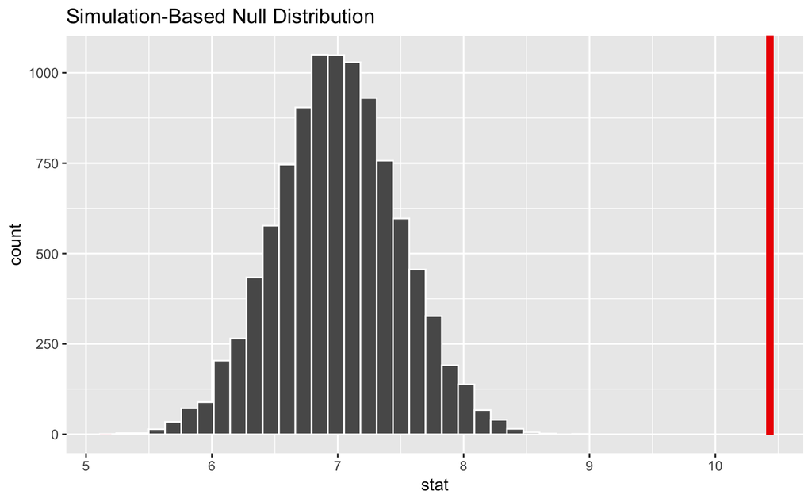

```r
null_distribution_Jabberwockies %>%
  visualise(bins = 30) +
# we add the statitsics (sample mean)
  shade_p_value(obs_stat = observed_stat$mean_sleep_hours, direction = "both")
```

And finally, we get the p-value.

```r
p_value <- null_distribution_Jabberwockies %>%
  get_p_value(obs_stat = observed_stat$mean_sleep_hours, direction = "both")
p_value
```

| p_value |
| --- |
| 0 |